# Unveiling the Evolution: A Decade of Social Media Platform Trends

Krishna Patel

January 21, 2024

```r
# Required packages for our course. Do not delete.
library(tidyverse)
library(mosaic)
library(ggplot2)
library(zoo)
library(lubridate)
```

# Big-picture

## Research Question

> In this infographic design, I will provide insights into the trends and characteristics of various social media platforms by analyzing their market share from 2009 to 2023. I will use data from the social media popularity dataset on Kaggle, which contains the percentage of share in the social media market for different platforms since 2009.

# Data

## Load data into R

```r
social_media <- read.csv("~/Desktop/BIOINFORMATICS_MS/Semester_IV/INSH5302/Project1/social_media.csv")
# first 10 rows
head(social_media, 10)
```

| Date | Facebook | Pinterest | Twitter | StumbleUpon | YouTube | Instagram | Tumblr | reddit | VKontakte | LinkedIn | Google. | Digg | MySpace | Fark | NowPublic | iWiW | news.ycombinator.com | Delicious | orkut | Odnoklassniki | Vimeo | Other |
| --- | --- | --- | --- | --- | --- | --- | --- | --- | --- | --- | --- | --- | --- | --- | --- | --- | --- | --- | --- | --- | --- | --- |
| 2009-04 | 20.16 | 0 | 6.86 | 36.79 | 0.00 | 0 | 0 | 8.98 | 0 | 0.00 | 0 | 6.70 | 14.81 | 0.22 | 0.04 | 0.29 | 0.08 | 0.49 | 1.75 | 0 | 0.00 | 2.83 |
| 2009-05 | 24.30 | 0 | 9.95 | 33.78 | 0.00 | 0 | 0 | 7.62 | 0 | 0.28 | 0 | 7.34 | 8.95 | 0.44 | 0.05 | 2.10 | 0.12 | 0.57 | 1.77 | 0 | 0.00 | 2.72 |
| 2009-06 | 26.48 | 0 | 10.56 | 29.65 | 0.00 | 0 | 0 | 12.13 | 0 | 0.49 | 0 | 5.90 | 7.66 | 0.66 | 0.05 | 2.35 | 0.11 | 0.58 | 1.46 | 0 | 0.00 | 1.93 |
| 2009-07 | 29.10 | 0 | 10.35 | 33.55 | 0.00 | 0 | 0 | 9.52 | 0 | 0.41 | 0 | 5.36 | 5.49 | 0.22 | 0.03 | 2.21 | 0.14 | 0.55 | 1.24 | 0 | 0.00 | 1.84 |
| 2009-08 | 34.25 | 0 | 11.15 | 29.01 | 0.00 | 0 | 0 | 9.37 | 0 | 0.45 | 0 | 4.56 | 4.69 | 0.40 | 0.08 | 2.27 | 0.08 | 0.52 | 1.27 | 0 | 0.00 | 1.90 |
| 2009-09 | 39.89 | 0 | 10.96 | 27.31 | 0.23 | 0 | 0 | 5.24 | 0 | 0.54 | 0 | 5.09 | 4.32 | 0.31 | 0.17 | 2.23 | 0.09 | 0.46 | 1.29 | 0 | 0.00 | 1.88 |
| 2009-10 | 36.60 | 0 | 8.75 | 25.73 | 10.79 | 0 | 0 | 5.38 | 0 | 0.40 | 0 | 3.53 | 3.46 | 0.28 | 0.22 | 1.93 | 0.09 | 0.35 | 0.98 | 0 | 0.04 | 1.47 |
| 2009-11 | 53.39 | 0 | 6.15 | 19.42 | 8.23 | 0 | 0 | 4.59 | 0 | 0.27 | 0 | 2.05 | 2.38 | 0.13 | 0.06 | 1.24 | 0.07 | 0.33 | 0.62 | 0 | 0.02 | 1.06 |
| 2009-12 | 74.39 | 0 | 3.36 | 10.55 | 5.06 | 0 | 0 | 2.51 | 0 | 0.14 | 0 | 1.46 | 0.62 | 0.21 | 0.03 | 0.65 | 0.03 | 0.23 | 0.33 | 0 | 0.02 | 0.39 |
| 2010-01 | 70.08 | 0 | 4.22 | 13.59 | 4.96 | 0 | 0 | 2.83 | 0 | 0.18 | 0 | 1.80 | 0.33 | 0.15 | 0.04 | 0.77 | 0.05 | 0.29 | 0.33 | 0 | 0.03 | 0.37 |

# Variables

```r
names(social_media)
```

```
##  [1] "Date"                 "Facebook"             "Pinterest"
##  [4] "Twitter"              "StumbleUpon"          "YouTube"
##  [7] "Instagram"            "Tumblr"               "reddit"
## [10] "VKontakte"            "LinkedIn"             "Google."
## [13] "Digg"                 "MySpace"              "Fark"
## [16] "NowPublic"            "iWiW"                 "news.ycombinator.com"
## [19] "Delicious"            "orkut"                "Odnoklassniki"
## [22] "Vimeo"                "Other"
```

The variables I used in my infographic design are:

1. Date
2. Twitter
3. Youtube
4. LinkedIn
5. Facebook

```r
subset_data <- social_media[, c("Facebook", "Twitter", "YouTube", "LinkedIn", "Date")]
selected_media <- subset_data[, c("Twitter", "YouTube", "LinkedIn", "Facebook")]

# Bar graph for average popularity of each social media selected
average_percentage <- colMeans(selected_media)
average_data <- data.frame(Platform = names(average_percentage), Average_Percentage = average_percentage)

# Print the average data values
print(average_data)
```

```
##          Platform Average_Percentage
## Twitter   Twitter          7.2667416
## YouTube   YouTube          3.7677528
## LinkedIn LinkedIn          0.2240449
## Facebook Facebook         69.2100562
```

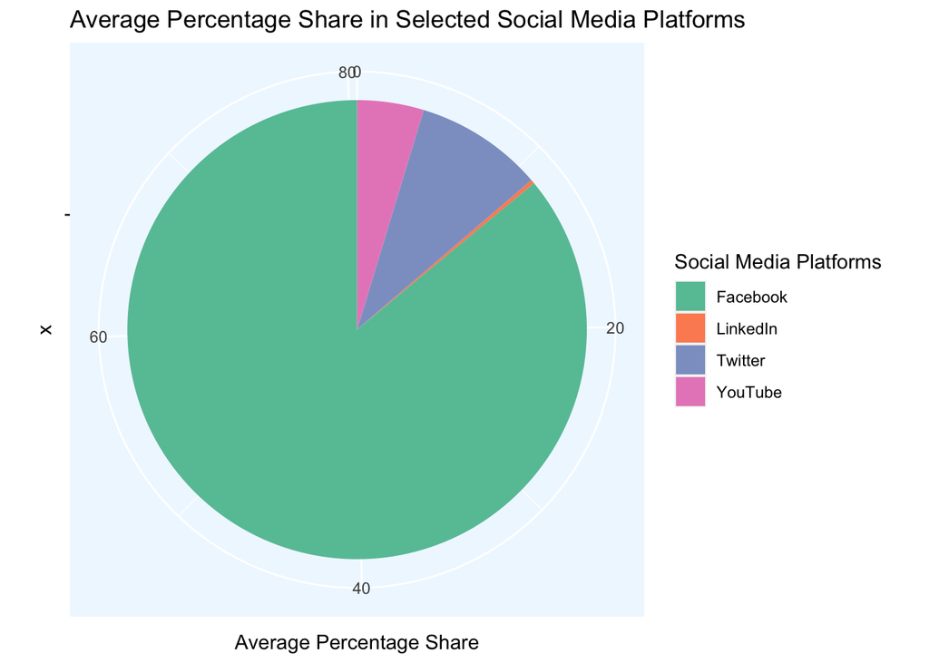

```r
# Plot the graph
ggplot(average_data, aes(x = "", y = Average_Percentage, fill = Platform)) +
  geom_col(width = 1) +
  coord_polar(theta = "y") +
  labs(title = "Average Percentage Share in Selected Social Media Platforms",
       fill = "Social Media Platforms",
       y = "Average Percentage Share") +
  theme(panel.background = element_rect(fill = "aliceblue")) +
  scale_fill_brewer(palette = "Set2")
```

> Among the platforms, Facebook stands out with the highest average percentage share at approximately 69.21%, indicating a dominant presence in terms of user engagement. Twitter follows with an average percentage share of approximately 7.27%, while YouTube and LinkedIn exhibit lower average shares at around 3.77% and 0.22%, respectively. These percentages offer insights into the relative popularity and user engagement levels on each platform, with Facebook notably capturing the majority of the overall engagement.

# Data Analysis

## Summary Statistics

```r
subset_data <- social_media[, c("Facebook", "Twitter", "YouTube", "LinkedIn", "Date")]

facebook_stat <- favstats(~ Facebook, data = subset_data)
print(facebook_stat)
```

```
##  min      Q1 median      Q3   max     mean      sd   n missing
##    0 64.6775 68.935 75.5275 87.83 69.21006 12.7224 178       0
```

```r
# Twitter
twitter_stat <- favstats(~ Twitter, data = subset_data)
print(twitter_stat)
```

```
##  min     Q1 median   Q3   max     mean      sd   n missing
##    0 5.5175   6.84 8.75 15.48 7.266742 2.55088 178       0
```

```r
# Youtube
youtube_stat <- favstats(~ YouTube, data = subset_data)
print(youtube_stat)
```

```
##  min    Q1 median    Q3   max     mean      sd   n missing
##    0 1.405  3.845 5.055 11.04 3.767753 2.67402 178       0
```

```r
# LinkedIn
linkedin_stat <- favstats(~ LinkedIn, data = subset_data)
print(linkedin_stat)
```

```
##  min   Q1 median  Q3  max      mean       sd   n missing
##    0 0.13   0.22 0.3 0.55 0.2240449 0.116087 178       0
```

> The descriptive statistics offer a comprehensive overview of engagement metrics for four prominent social media platforms: Facebook, Twitter, YouTube, and LinkedIn. In the case of Facebook, the engagement values span from a minimum of 0 to a maximum of 87.83, with a median value of 68.935. Twitter exhibits a range from 0 to 15.48, with a median engagement of 6.84. YouTube’s engagement statistics reveal a range from 0 to 11.04, with a median of 3.845. LinkedIn’s engagement metrics range from 0 to 0.55, with a median value of 0.22. The mean values, representing the average engagement, are 69.21 for Facebook, 7.27 for Twitter, 3.77 for YouTube, and 0.22 for LinkedIn. Standard deviation measures indicate the dispersion around the mean, with values of 12.72, 2.55, 2.67, and 0.12 for Facebook, Twitter, YouTube, and LinkedIn, respectively. These statistics, based on 178 observations for each platform, provide valuable insights into the central tendency, variability, and distribution of engagement levels across the specified social media platforms.

## Additional Analyses

```r
# Correlation between different social media platforms
selected_media <- subset_data[, c("Twitter", "YouTube", "LinkedIn", "Facebook")]
correlation_matrix <- cor(selected_media)
print(correlation_matrix)
```

```
##             Twitter    YouTube   LinkedIn   Facebook
## Twitter   1.0000000  0.1349487  0.4108647 -0.3349860
## YouTube   0.1349487  1.0000000  0.4969229 -0.2736100
## LinkedIn  0.4108647  0.4969229  1.0000000 -0.3780546
## Facebook -0.3349860 -0.2736100 -0.3780546  1.0000000
```

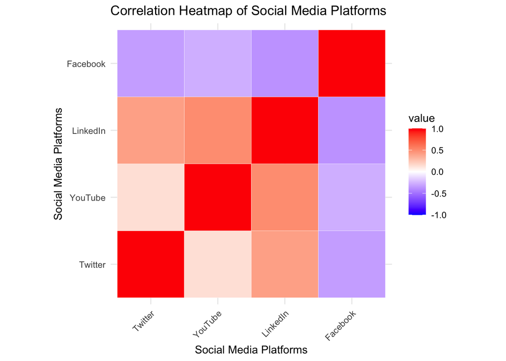

```r
ggplot(data = reshape2::melt(correlation_matrix), aes(Var1, Var2, fill = value)) +
  geom_tile(color = "white") +
  scale_fill_gradient2(low = "blue", high = "red", mid = "white", midpoint = 0, limit = c(-1, 1), space = "Lab") +
  theme_minimal() +
  theme(axis.text.x = element_text(angle = 45, hjust = 1)) +
  coord_fixed() +
  labs(title = "Correlation Heatmap of Social Media Platforms",
       x = "Social Media Platforms", y = "Social Media Platforms")
```

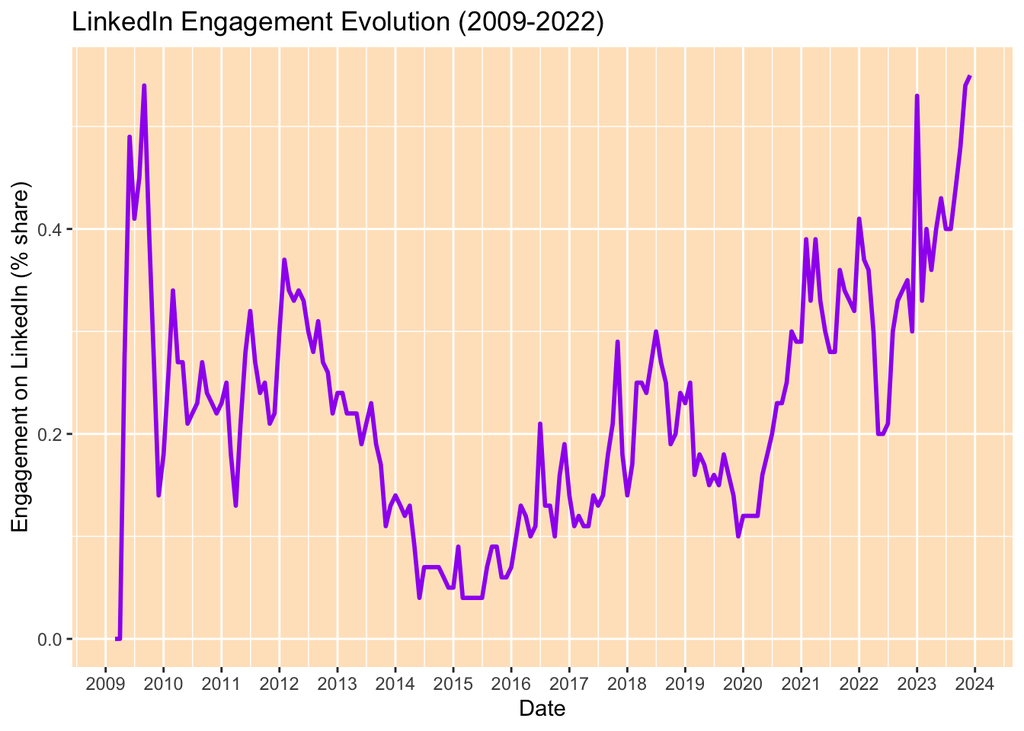

```r
# Scatterplot for each Social media platform over time
# Convert 'Date' column to Date type
social_media$Date <- as.Date(as.yearmon(social_media$Date, format = "%Y-%m"))

# Create a line plot for LinkedIn engagement evolution
ggplot(social_media, aes(x = Date, y = LinkedIn, group = 1, color = factor(year(Date)))) +
  geom_line(color = "purple", size = 1.0) +
  labs(title = "LinkedIn Engagement Evolution (2009-2022)",
       x = "Date",
       y = "Engagement on LinkedIn (% share)",
       color = "Year") +
  scale_x_date(date_breaks = "1 year", date_labels = "%Y") +
  scale_color_brewer(palette = "Set1") +
  theme(panel.background = element_rect(fill = "bisque"))
```

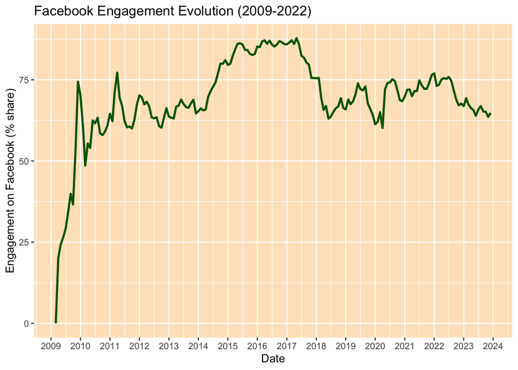

```r
subset_data_linkedin <- subset(social_media, year(Date) %in% seq(2009, 2022, 1))
write.csv(subset_data[, c("Date", "LinkedIn")], "linkedin_engagement_data.csv", row.names = FALSE)

# Create a line plot for Facebook engagement evolution
ggplot(social_media, aes(x = Date, y = Facebook, group = 1)) +
  geom_line(color = "darkgreen", size = 1.0) +
  labs(title = "Facebook Engagement Evolution (2009-2022)",
       x = "Date",
       y = "Engagement on Facebook (% share)") +
  scale_x_date(date_breaks = "1 year", date_labels = "%Y") +
  theme(panel.background = element_rect(fill = "bisque"))
```

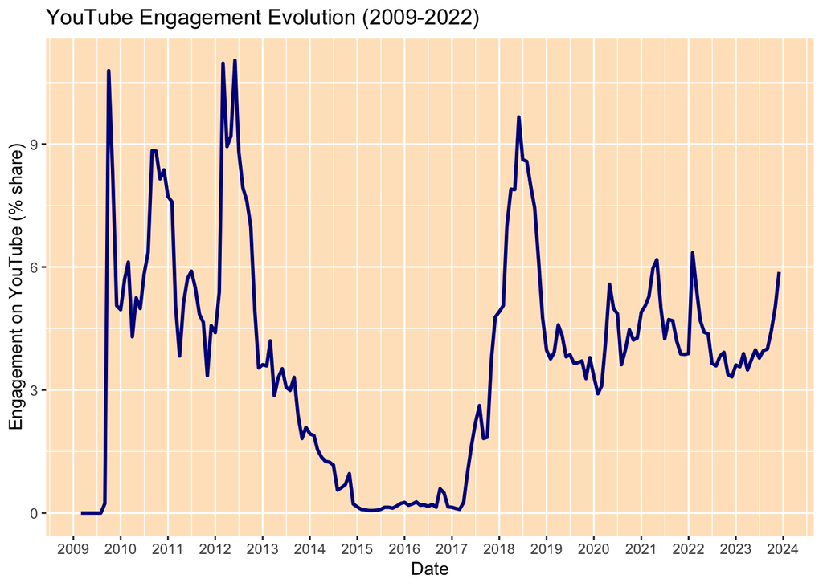

```r
# Create a line plot for YouTube engagement evolution
ggplot(social_media, aes(x = Date, y = YouTube, group = 1)) +
  geom_line(color = "darkblue", size = 1.0) +
  labs(title = "YouTube Engagement Evolution (2009-2022)",
       x = "Date",
       y = "Engagement on YouTube (% share)") +
  scale_x_date(date_breaks = "1 year", date_labels = "%Y") +
  theme(panel.background = element_rect(fill = "bisque"))
```

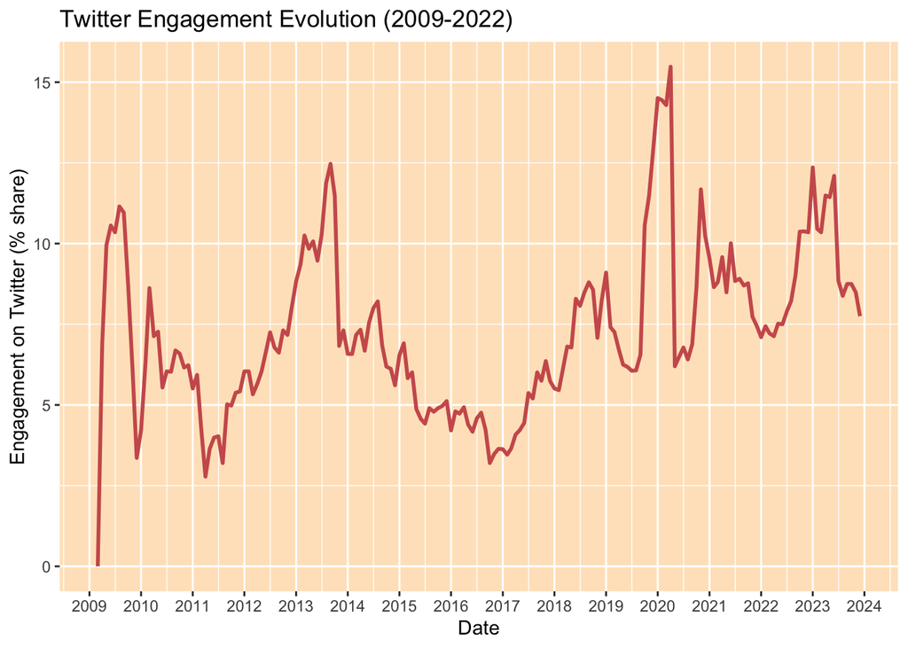

```r
# Create a line plot for Twitter engagement evolution
ggplot(social_media, aes(x = Date, y = Twitter, group = 1)) +
  geom_line(color = "indianred", size = 1.0) +
  labs(title = "Twitter Engagement Evolution (2009-2022)",
       x = "Date",
       y = "Engagement on Twitter (% share)") +
  scale_x_date(date_breaks = "1 year", date_labels = "%Y") +
  theme(panel.background = element_rect(fill = "bisque"))
```

> The provided R code conducts exploratory data analysis on social media engagement data. It begins by calculating the correlation matrix between Twitter, YouTube, LinkedIn, and Facebook, visualizing the correlations in a heatmap. The heatmap provides insights into the relationships between these platforms, with color gradients indicating the strength and direction of correlations.

> Notably, there is a moderate positive correlation between Twitter and LinkedIn, as well as between YouTube and LinkedIn. Conversely, a weak negative correlation is observed between Twitter and Facebook, YouTube and Facebook, and LinkedIn and Facebook. These insights suggest some level of interdependence in engagement trends across certain platforms, but the correlations are not strong, indicating that the dynamics influencing engagement on one platform may not consistently mirror those on another.

# Infographic

### (b)

Embed your design here:

[interactive chart not shown]

[Social Media Popularity Report](https://www.canva.com/design/DAF7xhH4YBc/watch?utm_content=DAF7xhH4YBc&utm_campaign=designshare&utm_medium=embeds&utm_source=link) by Patel Krishna**

### (c)

Provide a brief description of your data visualization process.

> At the beginning of the infographic, there’s a quick summary about the average share of different social media platforms. LinkedIn has the smallest share at 0.22%, and Facebook has the biggest share at a whopping 69.21%. This gives us a quick idea before we dive into looking at how social media engagement has changed over the years.

# References

1. https://www.kaggle.com/datasets/michau96/social-media-popularity-2009-2023?resource=download

## All done!

Knit the completed R Markdown file as a HTML document (click the “Knit” button at the top of the script editor window) and upload it to the submission portal on Canvas.